# Computer Assignment #4 (Machine Learning)

### Artificial Intelligence Course - Spring 2021

### Daneshvar Amrollahi (810197685)

#### The questions asked in the description are answered in the format Qi) where i is the question number.

# Pre-Processing

```python
import pandas as pd
pd.options.mode.chained_assignment = None  #ignoring warning
```

```python
df = pd.read_csv("data/vehicles.csv")
```

```python
df
```

|  | brand | category | created_at | description | image_count | mileage | price | title | year |
| --- | --- | --- | --- | --- | --- | --- | --- | --- | --- |
| 0 | NaN | heavy | Tuesday 07PM | سریال 43j$NUMبدون شکستگی سه حلقه لاستیک نو یک ... | 4 | NaN | -1 | لودر کاتر پیلار 950 | NaN |
| 1 | سایر | light | Wednesday 04AM | دوگانه ال پی جی بیمه با تخفیف دارد \nتودوزی نو... | 3 | 180000.0 | -1 | پاترول شش سیلندر چهار درب | 1366 |
| 2 | پژو ۴۰۵::Peugeot 405 | light | Wednesday 11AM | پژو 2000فنی تازه تعمیر بدنه بدون خطو خش تخیف ب... | 0 | 290000.0 | 8500000 | پژو مدل 81 مشکی | 1381 |
| 3 | نیسان::Nissan | light | Wednesday 01PM | سلام.\nماشین کاملا سالم همه چی فابریک متور زد ... | 3 | 175000.0 | 19500000 | پاترول 2در | 1372 |
| 4 | سمند::Samand | light | Thursday 07AM | سمند ال ایکس بدون رنگ تمامی سرویس ها انجام شده... | 4 | 80000.0 | 23900000 | سمند دوگانه کارخانه | 1391 |
| ... | ... | ... | ... | ... | ... | ... | ... | ... | ... |
| 130438 | NaN | heavy | Wednesday 03PM | بادسان فوق بیرنگ سفید رنگ بیمه تابرج 3.96 تخفی... | 2 | NaN | 48000000 | بادسان 8b14 مدل83 | NaN |
| 130439 | NaN | heavy | Wednesday 06PM | باسلام .تراکتورازصفری دست خودم بوده.سالم.ودارا... | 4 | NaN | -1 | تراکتورگلدونی ۲۳۸ایتالیا | NaN |
| 130440 | سمند::Samand | light | Wednesday 06PM | ماشینم تصادفیه با خریدار توافق میکنم سر قیمتش | 3 | 20000.0 | -1 | خودرو سمند تصادفی مدل92 | 1392 |
| 130441 | پراید صندوق‌دار::Pride | light | Thursday 03PM | سند۲ برگ،بیمه تا برج$NUMتخفیفات بیمه 15 سال،مع... | 4 | 123000.0 | 6900000 | پراید 79 بسیار سالم | 1379 |
| 130442 | پراید صندوق‌دار::Pride | light | Friday 04PM | پراید دوگانه کارخانه میباشد و کم کارکرد.روکش .... | 3 | 43000.0 | 17400000 | پراید دوگانه کارخانه مدل93 | 1393 |

130443 rows × 9 columns

```python
df.describe()
```

|  | image_count | mileage | price |
| --- | --- | --- | --- |
| count | 130443.000000 | 120451.000000 | 1.304430e+05 |
| mean | 1.865527 | 100862.291944 | 2.224718e+07 |
| std | 1.471163 | 98368.470916 | 3.079805e+07 |
| min | 0.000000 | 0.000000 | -1.000000e+00 |
| 25% | 0.000000 | 19000.000000 | 7.400000e+06 |
| 50% | 2.000000 | 75000.000000 | 1.450000e+07 |
| 75% | 3.000000 | 160000.000000 | 2.500000e+07 |
| max | 14.000000 | 500000.000000 | 4.000000e+08 |

First, we drop the rows with **price = -1**:

```python
df = df[df.price != -1]
```

```python
df
```

|  | brand | category | created_at | description | image_count | mileage | price | title | year |
| --- | --- | --- | --- | --- | --- | --- | --- | --- | --- |
| 2 | پژو ۴۰۵::Peugeot 405 | light | Wednesday 11AM | پژو 2000فنی تازه تعمیر بدنه بدون خطو خش تخیف ب... | 0 | 290000.0 | 8500000 | پژو مدل 81 مشکی | 1381 |
| 3 | نیسان::Nissan | light | Wednesday 01PM | سلام.\nماشین کاملا سالم همه چی فابریک متور زد ... | 3 | 175000.0 | 19500000 | پاترول 2در | 1372 |
| 4 | سمند::Samand | light | Thursday 07AM | سمند ال ایکس بدون رنگ تمامی سرویس ها انجام شده... | 4 | 80000.0 | 23900000 | سمند دوگانه کارخانه | 1391 |
| 5 | پژو ۴۰۵::Peugeot 405 | light | Thursday 08AM | بیمه یکسال ده سال تخفیف دور رنگ شاسی پلمپ سالم | 3 | 125000.0 | 8500000 | پژو405 مدل84 | 1384 |
| 6 | ام‌وی‌ام::MVM | light | Thursday 08AM | ام وی ام چهار سیلندر مدل 93 فنی سالم بدون رنگ ... | 2 | 11000.0 | 18500000 | ام وی ام 110 چهار سیلندر | 1393 |
| ... | ... | ... | ... | ... | ... | ... | ... | ... | ... |
| 130435 | تندر ۹۰::Tondar 90 | light | Tuesday 02PM | فوق‌العاده سالم بدون رنگ دزدگیر ماجیکار شیشه ه... | 2 | 173000.0 | 30000000 | ال۹۰ E2 | 1390 |
| 130436 | پراید صندوق‌دار::Pride | light | Tuesday 05PM | مدل 84 تمیز. بدون رنگ. سیستم صوتی. رینگ و لاست... | 3 | 140000.0 | 11000000 | پراید مدل 84 بدون رنگ | 1384 |
| 130438 | NaN | heavy | Wednesday 03PM | بادسان فوق بیرنگ سفید رنگ بیمه تابرج 3.96 تخفی... | 2 | NaN | 48000000 | بادسان 8b14 مدل83 | NaN |
| 130441 | پراید صندوق‌دار::Pride | light | Thursday 03PM | سند۲ برگ،بیمه تا برج$NUMتخفیفات بیمه 15 سال،مع... | 4 | 123000.0 | 6900000 | پراید 79 بسیار سالم | 1379 |
| 130442 | پراید صندوق‌دار::Pride | light | Friday 04PM | پراید دوگانه کارخانه میباشد و کم کارکرد.روکش .... | 3 | 43000.0 | 17400000 | پراید دوگانه کارخانه مدل93 | 1393 |

110054 rows × 9 columns

```python
df.dtypes
```

```
brand           object
category        object
created_at      object
description     object
image_count      int64
mileage        float64
price            int64
title           object
year            object
dtype: object
```

### Replacing NaN values:

```python
for col in list(df.columns):
    print(col,"has {0} NaN values".format(df[col].isna().sum()))
```

```
brand has 6255 NaN values
category has 0 NaN values
created_at has 0 NaN values
description has 0 NaN values
image_count has 0 NaN values
mileage has 6255 NaN values
price has 0 NaN values
title has 0 NaN values
year has 6255 NaN values
```

We have NaN values in the following columns:

1. brand
2. mileage
3. year

#### Q4)

We decided to replace **NaN** values in each column with the most frequent data in that column since we don't like to drop one whole row because of a single value missing.

```python
nan_cols = ["brand","mileage", "year"]
print(df[nan_cols].mode())
```

```
                    brand   mileage  year
0  پراید صندوق‌دار::Pride  200000.0  1393
```

```python
for col in nan_cols:
    print("Column {} has {} NaN values".format(col, df[col].isna().sum()))
```

```
Column brand has 6255 NaN values
Column mileage has 6255 NaN values
Column year has 6255 NaN values
```

```python
df.loc[:,"brand"].fillna("پراید صندوق‌دار::Pride", inplace = True)
df.loc[:,"mileage"].fillna("200000.0", inplace = True)
df.loc[:,"year"].fillna("1393", inplace = True)
```

```python
for col in nan_cols:
    print("Column {} has {} NaN values".format(col, df[col].isna().sum()))
```

```
Column brand has 0 NaN values
Column mileage has 0 NaN values
Column year has 0 NaN values
```

Now we convert the categorial values:

1. brand
2. category
3. created_at
4. description
5. title
6. year

to numerical values so we can use the **mutual_info_regression()** method which only works with numerical values:

```python
df['year'].value_counts()
```

```
1393     17153
1390      8793
1394      8571
1389      7062
1391      6449
1388      6436
1383      5753
1386      5625
1387      5604
1392      5534
1385      5459
1384      5392
1395      5279
1382      4528
1381      3354
```

[output cut: 17 more lines]

```python
df["year"].replace({"<1366": "1366"}, inplace=True)

df['year'] = df['year'].astype(int)
```

#### Q2)

There are many ways to convert categorical data into numerical datas. Here we use 2 of them:

1. **Label Encoders**: Assigining numbers to each categorical value.
2. **One Hot Encoding**: Adding new columns for each categorical value and assigining a binary vector for each row.

**Label Encoders** aren't a good option when we have no particular ordering in our categories. In these cases, we can use **One Hot Encoding** which takes a lot of memory since it is adding a new column for each new category.

```python
from sklearn.preprocessing import OrdinalEncoder
pd.options.mode.chained_assignment = None  # default='warn'

numerical_cols = list(df._get_numeric_data().columns)
categorical_cols = [x for x in list(df.columns) if x not in numerical_cols]


categorical_cols.remove('description')
categorical_cols.remove('title')
print(categorical_cols)

ord_enc = OrdinalEncoder()

df[categorical_cols] = ord_enc.fit_transform(df[categorical_cols].astype(str))
```

```
['brand', 'category', 'created_at', 'mileage']
```

### Converting all floats to int:

```python
df['brand'] = df['brand'].astype(int)
df['category'] = df['category'].astype(int)
df['created_at'] = df['created_at'].astype(int)
df['category'] = df['category'].astype(int)
df['mileage']= df['mileage'].astype(int)
```

```python
df.head(10)
```

|  | brand | category | created_at | description | image_count | mileage | price | title | year |
| --- | --- | --- | --- | --- | --- | --- | --- | --- | --- |
| 2 | 23 | 1 | 164 | پژو 2000فنی تازه تعمیر بدنه بدون خطو خش تخیف ب... | 0 | 1752 | 8500000 | پژو مدل 81 مشکی | 1381 |
| 3 | 13 | 1 | 145 | سلام.\nماشین کاملا سالم همه چی فابریک متور زد ... | 3 | 842 | 19500000 | پاترول 2در | 1372 |
| 4 | 11 | 1 | 108 | سمند ال ایکس بدون رنگ تمامی سرویس ها انجام شده... | 4 | 2978 | 23900000 | سمند دوگانه کارخانه | 1391 |
| 5 | 23 | 1 | 110 | بیمه یکسال ده سال تخفیف دور رنگ شاسی پلمپ سالم | 3 | 335 | 8500000 | پژو405 مدل84 | 1384 |
| 6 | 0 | 1 | 110 | ام وی ام چهار سیلندر مدل 93 فنی سالم بدون رنگ ... | 2 | 105 | 18500000 | ام وی ام 110 چهار سیلندر | 1393 |
| 7 | 17 | 1 | 112 | یک پراید مدل 87خونگی بدون رنگ سفید هفت سال تخف... | 1 | 1054 | 11000000 | پرایدصبامدل87خونگی فابریک | 1387 |
| 8 | 18 | 1 | 6 | مدل 80 رنگ سفید بیمه تا برج ۱۱ فنی سالم رینگ ... | 3 | 1 | 7800000 | پراید هاچ بک مدل 80 | 1380 |
| 9 | 10 | 1 | 23 | در حد_ بسیار تمیز_ سرویس گارانتی انجام شده_ ما... | 1 | 800 | 45000000 | جک جی ۵ دنده ای | 1393 |
| 10 | 17 | 0 | 11 | مدل ۸۲برج۱۲بدون رنگ بیمه بدنه وثالث ۱۳سال تخفی... | 4 | 1054 | 222000000 | اف ام جفت باری | 1393 |
| 12 | 17 | 1 | 71 | پرایددوگانه فابریک سفیدفنی درجه یک تازه تعمیرب... | 3 | 1488 | 11000000 | پراید دوگانه فابربک | 1388 |

```python
df.dtypes
```

```
brand           int64
category        int64
created_at      int64
description    object
image_count     int64
mileage         int64
price           int64
title          object
year            int64
dtype: object
```

Now we drop the categorical columns which we don't want to include in our **mutual info** calculation.

```python
y = df['price']

X = df

X = X.drop(columns=['description', 'title', 'price'], axis = 1)
```

```python
X.head(10)
```

|  | brand | category | created_at | image_count | mileage | year |
| --- | --- | --- | --- | --- | --- | --- |
| 2 | 23 | 1 | 164 | 0 | 1752 | 1381 |
| 3 | 13 | 1 | 145 | 3 | 842 | 1372 |
| 4 | 11 | 1 | 108 | 4 | 2978 | 1391 |
| 5 | 23 | 1 | 110 | 3 | 335 | 1384 |
| 6 | 0 | 1 | 110 | 2 | 105 | 1393 |
| 7 | 17 | 1 | 112 | 1 | 1054 | 1387 |
| 8 | 18 | 1 | 6 | 3 | 1 | 1380 |
| 9 | 10 | 1 | 23 | 1 | 800 | 1393 |
| 10 | 17 | 0 | 11 | 4 | 1054 | 1393 |
| 12 | 17 | 1 | 71 | 3 | 1488 | 1388 |

```python
from sklearn.model_selection import train_test_split
from sklearn.feature_selection import mutual_info_regression

X_train, X_test, y_train, y_test = train_test_split(X, y, test_size = 0.4, random_state = 0)
mi = mutual_info_regression(X_train, y_train)
mi = pd.Series(mi)
mi.index = X_train.columns
mi.sort_values(ascending = False, inplace = True)

mi
```

```
year           0.381298
brand          0.269676
category       0.073586
mileage        0.067430
image_count    0.005853
created_at     0.000000
dtype: float64
```

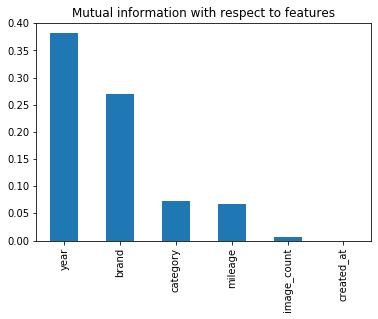

```python
import matplotlib.pyplot as plt

plt.title('Mutual information with respect to features')
mi.plot.bar()
plt.show()
```

#### Q1)

This plot shows that only the columns year, brand, category, and mileage are giving us useful info about the price of each row. We can simply eliminate the other columns since they don't have much gain.

### Words Exctraction:

```python
with open('stop_words.txt') as f:
    ignore = [line.rstrip() for line in f]

ignore = [x.strip() for x in ignore]
print("Some stop words:")
print(ignore[30:45])
```

```
Some stop words:
['آزادانه', 'آسان', 'آسيب پذيرند', 'آشكارا', 'آشنايند', 'آمرانه', 'آن', 'آن گاه', 'آن ها', 'آنان', 'آناني', 'آنجا', 'آنچنان', 'آنچنان كه', 'آنچه']
```

```python
import hazm
from collections import Counter

words_cnt = Counter()

for sentence in df['description']:
    words = hazm.word_tokenize(sentence)
    for w in words:
        if w in ignore:
            continue

        words_cnt[w] = words_cnt.get(w, 0) + 1
```

```python
import hazm
from collections import Counter

words_cnt = Counter()

for sentence in df['title']:
    words = hazm.word_tokenize(sentence)
    for w in words:
        if w in ignore:
            continue

        words_cnt[w] = words_cnt.get(w, 0) + 1
```

```python
most_common_words = words_cnt.most_common(50)
for word in most_common_words[:50]:
    print(word)
```

[output not shown]

### One Hot Encoding:

We use one hot encoding for the following features:

1. Brand
2. Heavy/Light category
3. 10 most common words

```python
brand_one_hot = pd.get_dummies(df['brand'], prefix='brand')
df = df.drop(['brand'], axis = 1)
df = pd.concat([df, brand_one_hot], axis = 1)
```

```python
cat_one_hot = pd.get_dummies(df['category'], prefix = 'cat')
df = df.drop(['category'], axis = 1)
df = pd.concat([df, cat_one_hot], axis = 1)
```

```python
from sklearn.feature_extraction.text import CountVectorizer
import hazm

ndf = df.drop(['description', 'title'], axis = 1)
ndf = ndf.reset_index()


words = ['دوگانه', 'روکش', 'تخفیف', 'نو', 'رنگ', 'وانت', 'مدادی', 'سالم', 'بیمه', 'سفید']

cnt_vec = CountVectorizer(analyzer = 'word', tokenizer = hazm.word_tokenize)

fit = cnt_vec.fit_transform(df['description'])
indices = [cnt_vec.vocabulary_[word] for word in words]
sel_fit = fit[:, indices].toarray()
print(sel_fit.sum(axis = 0))
ndf[words] = pd.DataFrame(sel_fit, columns = words)


display(ndf)
```

```
[11642 11117 37424 24745 64515  1696  2323 45859 74031  9896]
```

|  | index | created_at | image_count | mileage | price | year | brand_0 | brand_1 | brand_2 | brand_3 | ... | دوگانه | روکش | تخفیف | نو | رنگ | وانت | مدادی | سالم | بیمه | سفید |
| --- | --- | --- | --- | --- | --- | --- | --- | --- | --- | --- | --- | --- | --- | --- | --- | --- | --- | --- | --- | --- | --- |
| 0 | 2 | 164 | 0 | 1752 | 8500000 | 1381 | 0 | 0 | 0 | 0 | ... | 0 | 0 | 0 | 0 | 0 | 0 | 0 | 0 | 2 | 0 |
| 1 | 3 | 145 | 3 | 842 | 19500000 | 1372 | 0 | 0 | 0 | 0 | ... | 1 | 0 | 0 | 1 | 0 | 0 | 0 | 1 | 0 | 0 |
| 2 | 4 | 108 | 4 | 2978 | 23900000 | 1391 | 0 | 0 | 0 | 0 | ... | 0 | 0 | 0 | 0 | 1 | 0 | 0 | 0 | 0 | 0 |
| 3 | 5 | 110 | 3 | 335 | 8500000 | 1384 | 0 | 0 | 0 | 0 | ... | 0 | 0 | 1 | 0 | 1 | 0 | 0 | 1 | 1 | 0 |
| 4 | 6 | 110 | 2 | 105 | 18500000 | 1393 | 1 | 0 | 0 | 0 | ... | 0 | 0 | 1 | 0 | 1 | 0 | 0 | 1 | 1 | 0 |
| ... | ... | ... | ... | ... | ... | ... | ... | ... | ... | ... | ... | ... | ... | ... | ... | ... | ... | ... | ... | ... | ... |
| 110049 | 130435 | 123 | 2 | 822 | 30000000 | 1390 | 0 | 0 | 0 | 1 | ... | 0 | 1 | 0 | 0 | 1 | 0 | 0 | 1 | 0 | 0 |
| 110050 | 130436 | 129 | 3 | 531 | 11000000 | 1384 | 0 | 0 | 0 | 0 | ... | 0 | 0 | 0 | 0 | 1 | 0 | 0 | 0 | 1 | 0 |
| 110051 | 130438 | 149 | 2 | 1054 | 48000000 | 1393 | 0 | 0 | 0 | 0 | ... | 0 | 0 | 1 | 0 | 1 | 0 | 0 | 0 | 1 | 1 |
| 110052 | 130441 | 101 | 4 | 281 | 6900000 | 1379 | 0 | 0 | 0 | 0 | ... | 0 | 0 | 0 | 0 | 1 | 0 | 0 | 2 | 2 | 0 |
| 110053 | 130442 | 7 | 3 | 2379 | 17400000 | 1393 | 0 | 0 | 0 | 0 | ... | 1 | 1 | 0 | 0 | 0 | 0 | 0 | 0 | 1 | 0 |

110054 rows × 44 columns

### Normalization:

```python
X = ndf.drop(['price', 'index'], axis = 1)
y = ndf['price']
```

```python
def normalize(df):
    result = df.copy()
    for feature_name in df.columns:
        max_value = df[feature_name].max()
        min_value = df[feature_name].min()
        result[feature_name] = (df[feature_name] - min_value) / (max_value - min_value)
    return result

X = normalize(X)
```

```python
X
```

|  | created_at | image_count | mileage | year | brand_0 | brand_1 | brand_2 | brand_3 | brand_4 | brand_5 | ... | دوگانه | روکش | تخفیف | نو | رنگ | وانت | مدادی | سالم | بیمه | سفید |
| --- | --- | --- | --- | --- | --- | --- | --- | --- | --- | --- | --- | --- | --- | --- | --- | --- | --- | --- | --- | --- | --- |
| 0 | 0.982036 | 0.000000 | 0.548700 | 0.517241 | 0.0 | 0.0 | 0.0 | 0.0 | 0.0 | 0.0 | ... | 0.000000 | 0.00 | 0.0 | 0.000000 | 0.000000 | 0.0 | 0.0 | 0.000000 | 0.4 | 0.00 |
| 1 | 0.868263 | 0.214286 | 0.263702 | 0.206897 | 0.0 | 0.0 | 0.0 | 0.0 | 0.0 | 0.0 | ... | 0.333333 | 0.00 | 0.0 | 0.111111 | 0.000000 | 0.0 | 0.0 | 0.142857 | 0.0 | 0.00 |
| 2 | 0.646707 | 0.285714 | 0.932665 | 0.862069 | 0.0 | 0.0 | 0.0 | 0.0 | 0.0 | 0.0 | ... | 0.000000 | 0.00 | 0.0 | 0.000000 | 0.166667 | 0.0 | 0.0 | 0.000000 | 0.0 | 0.00 |
| 3 | 0.658683 | 0.214286 | 0.104917 | 0.620690 | 0.0 | 0.0 | 0.0 | 0.0 | 0.0 | 0.0 | ... | 0.000000 | 0.00 | 0.2 | 0.000000 | 0.166667 | 0.0 | 0.0 | 0.142857 | 0.2 | 0.00 |
| 4 | 0.658683 | 0.142857 | 0.032884 | 0.931034 | 1.0 | 0.0 | 0.0 | 0.0 | 0.0 | 0.0 | ... | 0.000000 | 0.00 | 0.2 | 0.000000 | 0.166667 | 0.0 | 0.0 | 0.142857 | 0.2 | 0.00 |
| ... | ... | ... | ... | ... | ... | ... | ... | ... | ... | ... | ... | ... | ... | ... | ... | ... | ... | ... | ... | ... | ... |
| 110049 | 0.736527 | 0.142857 | 0.257438 | 0.827586 | 0.0 | 0.0 | 0.0 | 1.0 | 0.0 | 0.0 | ... | 0.000000 | 0.25 | 0.0 | 0.000000 | 0.166667 | 0.0 | 0.0 | 0.142857 | 0.0 | 0.00 |
| 110050 | 0.772455 | 0.214286 | 0.166301 | 0.620690 | 0.0 | 0.0 | 0.0 | 0.0 | 0.0 | 0.0 | ... | 0.000000 | 0.00 | 0.0 | 0.000000 | 0.166667 | 0.0 | 0.0 | 0.000000 | 0.2 | 0.00 |
| 110051 | 0.892216 | 0.142857 | 0.330097 | 0.931034 | 0.0 | 0.0 | 0.0 | 0.0 | 0.0 | 0.0 | ... | 0.000000 | 0.00 | 0.2 | 0.000000 | 0.166667 | 0.0 | 0.0 | 0.000000 | 0.2 | 0.25 |
| 110052 | 0.604790 | 0.285714 | 0.088005 | 0.448276 | 0.0 | 0.0 | 0.0 | 0.0 | 0.0 | 0.0 | ... | 0.000000 | 0.00 | 0.0 | 0.000000 | 0.166667 | 0.0 | 0.0 | 0.285714 | 0.4 | 0.00 |
| 110053 | 0.041916 | 0.214286 | 0.745067 | 0.931034 | 0.0 | 0.0 | 0.0 | 0.0 | 0.0 | 0.0 | ... | 0.333333 | 0.25 | 0.0 | 0.000000 | 0.000000 | 0.0 | 0.0 | 0.000000 | 0.2 | 0.00 |

110054 rows × 42 columns

```python
y
```

```
0          8500000
1         19500000
2         23900000
3          8500000
4         18500000
            ...
110049    30000000
110050    11000000
110051    48000000
110052     6900000
110053    17400000
Name: price, Length: 110054, dtype: int64
```

# Testing

```python
from sklearn.metrics import mean_squared_error
from sklearn.neighbors import KNeighborsRegressor
from sklearn.linear_model import LinearRegression
from sklearn import tree
from sklearn.ensemble import RandomForestRegressor

from matplotlib import pyplot as plt
```

### K Nearest Neighbors:

```python
X_train, X_test, y_train, y_test = train_test_split(X, y, test_size = 0.3, random_state = 0)

KNN = KNeighborsRegressor(n_neighbors = 277)
KNN.fit(X_train, y_train)
price_KNN = KNN.predict(X_test)
```

```python
from sklearn.metrics import mean_squared_error
print('RMSE:', mean_squared_error(price_KNN, y_test, squared = False))
print('MSE:', mean_squared_error(price_KNN, y_test, squared = True))
```

```
RMSE: 20494922.70176875
MSE: 420041856551476.06
```

### Linear Regression

```python
X_train, X_test, y_train, y_test = train_test_split(X, y, test_size = 0.25, random_state = 0)

lin_reg = LinearRegression()
lin_reg.fit(X_train, y_train)
price_lin = lin_reg.predict(X_test)
```

```python
print('RMSE:', mean_squared_error(price_lin, y_test, squared = False))
print('MSE:', mean_squared_error(price_lin, y_test, squared = True))
print("Train: 75%    Test: 25%")
```

```
RMSE: 20631572.543875776
MSE: 425661785633208.75
Train: 75%    Test: 25%
```

```python
X_train, X_test, y_train, y_test = train_test_split(X, y, test_size = 0.02, random_state = 0)

lin_reg = LinearRegression()
lin_reg.fit(X_train, y_train)
price_lin = lin_reg.predict(X_test)
```

```python
print('RMSE:', mean_squared_error(price_lin, y_test, squared = False))
print('MSE:', mean_squared_error(price_lin, y_test, squared = True))
print("Train: 98%    Test: 2%")
```

```
RMSE: 21032410.180147715
MSE: 442362277985981.2
Train: 98%    Test: 2%
```

**Overfitting**: The model corresponds too closely to fit e train data. Therefore, it does not work well on the test data which is new.

```python
X_train, X_test, y_train, y_test = train_test_split(X, y, test_size = 0.6, random_state = 0)

lin_reg = LinearRegression()
lin_reg.fit(X_train, y_train)
price_lin = lin_reg.predict(X_test)
```

```python
print('RMSE:', mean_squared_error(price_lin, y_test, squared = False))
print('MSE:', mean_squared_error(price_lin, y_test, squared = True))
print("Train: 60%    Test: 40%")
```

[output not shown]

**Underfitting**: The model could have been trained better if we provided it with more train data.

#### Q5)

As it can be seen, the case where we splitted the data as **75% train** and **25% train**, we achieved **the least RMSE** in compare to the other cases where we had over/under-fitting

### Decision Trees

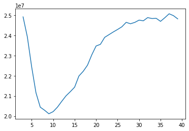

```python
X_train, X_test, y_train, y_test = train_test_split(X, y, test_size = 0.25, random_state = 0)


n = [i for i in range(3, 40)]
err = [0 for i in range(3, 40)]

for i in range(len(n)):
    decision_tree = tree.DecisionTreeRegressor(max_depth = n[i], min_samples_split = 2)
    decision_tree.fit(X_train, y_train)
    price_decision_tree = decision_tree.predict(X_test)
    err[i] = mean_squared_error(price_decision_tree, y_test, squared = False)

plt.plot(n, err)
plt.show()
```

#### Q6)

A too shallow decision tree --> underfitting

A too deep decision tree --> overfitting

The optimal depth for the decision tree seems to be 8-9 according to the plot.

### Random Forsest

```python
X_train, X_test, y_train, y_test = train_test_split(X, y, test_size = 0.25, random_state = 0)

random_forest = RandomForestRegressor(bootstrap = True, n_estimators = 200, max_samples = 50000, max_depth = 12, min_samples_split = 10)
random_forest.fit(X_train, y_train)
price_random_forest = random_forest.predict(X_test)
```

```python
print('RMSE:', mean_squared_error(price_random_forest, y_test, squared = False))
print('n_estimators: 200   max_depth: 12')
```

```
RMSE: 18825917.198891293
n_estimators: 200   max_depth: 12
```

```python
random_forest = RandomForestRegressor(bootstrap = True, n_estimators = 20, max_samples = 50000, max_depth = 12, min_samples_split = 10)
random_forest.fit(X_train, y_train)
price_random_forest = random_forest.predict(X_test)
```

```python
print('RMSE:', mean_squared_error(price_random_forest, y_test, squared = False))
print('n_estimators: 20   max_depth: 12')
```

```
RMSE: 18948778.5041513
n_estimators: 20   max_depth: 12
```

Decreasing the number of estimators, increases RMSE.

```python
random_forest = RandomForestRegressor(bootstrap = True, n_estimators = 200, max_samples = 50000, max_depth = 6, min_samples_split = 10)
random_forest.fit(X_train, y_train)
price_random_forest = random_forest.predict(X_test)
```

```python
print('RMSE:', mean_squared_error(price_random_forest, y_test, squared = False))
print('n_estimators: 20   max_depth: 6')
```

[output not shown]

Decreasing the max_depth, increases RMSE.